# Methods

## Step 1: Estimate Biological & Fishery Parameters

The first step of the analysis is to determine several important biological and stock-level parameters for *S. lemuru*, including the allometric length-weight relationship, natural mortality ($M$), selectivity, the average weight of an individual in the catch ($\bar{w}$), and the number of individuals in the catch ($n$).

### Growth

Growth of *S. lemuru* is modeled using the Von Bertalanffy growth parameters from Setyohadi *et al.* (2010).

- $K = 1.29$
- $L_{\infty} = 22.1 cm$
- $t_0 = -0.08$

Length-at-age is then estimated according to the Von Bertalanffy growth equation as follows:

$$L_a = 22.1 (1-e^{-1.29(a + 0.08)})$$
The above equation represents annual growth and is subsequently modified to reflect monthly growth of *S. lemuru*

$$L_a = 22.1 (1-e^{\frac{1}{12}(-1.29(a + 0.08))})$$

### Natural Mortality

Table 1: Previous estimates of total mortality (Z), natural mortality (M), and fishing mortality (F) for Bali sardine fishery in Indonesia

| Z | M | F | Location | Study |
| --- | --- | --- | --- | --- |
| 4.48 | 1.00 | 3.38 | Selat Bali | Merta, 1992 |
| 6.33 | 2.29 | 4.03 | Selat Bali | Setyohadi, 2010 |

### Catch Weight and Number

Length frequency data for *S. lemuru* was recorded from June-August for fishing area 4 and from August-October for fishing area 6 off Zamboanga del Norte (Figure 1.)

[figure not shown]

Figure 1: Bali sardine fishing grounds off Zamboanga del Norte

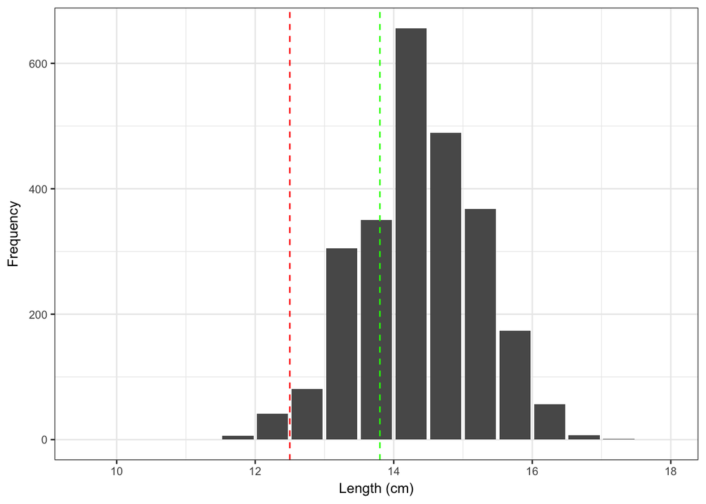

Figure 2. Length-frequency for Bali sardine caught by the Municiapl gillnet fleet in fishing areas 4 and 6 off Zamboanga del Norte. The red dotted line represent average length at first maturity and the green dotted line is the length of highest recorded fecundity

Using the length-frequency data and the general allometric length-weight equation, the average weight ($\bar{w}$) of an individual in the data is estimated as follows:

$$\bar{w} = \sum\limits_{9.97}^l \frac{w_l}{n_l}$$

The total number of individuals in the catch ($N$) is then estimated by dividing the total catch weight ($W$) in the most recent year by ($\bar{w}$).

$$N = \frac{W}{\bar{w}}$$

### Selectivity

Selectivity for the Philippine *S. lemuru* drift gillnet fishery come from Setyohadi *et al.* (2013), who estimated the selectivity of drift gillnets to *S. lemuru* in Indonesia. This study evaluated two gillnet mesh sizes, 2.54 cm and 3.175 cm, which are the same sizes used by the *S. lemuru* fishery in the Philippines. Setyohadi *et al.* (2013) found the gear selection factor ($S$) of the gillnet to the catch of *S. lemuru* to be 5.89, and the optimum length ($L_{opt}$) of *S. lemuru* to the 2.54 cm and 3.175 cm gillnets to be 14.96 cm and 18.7 cm, respectively. The standard deviation of both selection curves was 1.747 cm. Given the two $L_{opt}$ values $L_{opt,A}, L_{opt,B}$ and the shared standard deviation ($sd$), the probability of capture ($P$) at a given length ($L$) was calculated for each mesh size as follows:

$$P_A = exp(-\frac{(L - L_A)^2}{2sd^2})$$
$$P_B = exp(-\frac{(L - L_B)^2}{2sd^2})$$

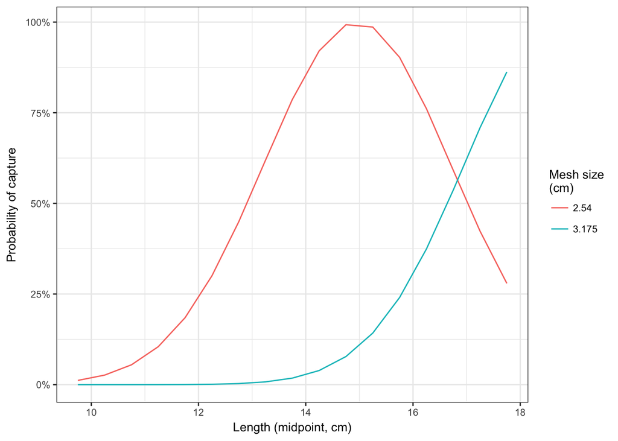

Figure 3. Selectivity curves for S. lemuru caught by drift gillnets with 2.54 and 3.175 cm mesh sizes

## Step 2: Set Final Depletion

The *S. lemuru* fishery in the Philippines is data-poor and no reliable estimates of stock status currently exist, nor does sufficient publicly available data to conduct such an analysis. As a result, this model operates by first requiring the user to specify an educated guess at the current level of depletion ($B/K$). This assumption allows estimation of the remaining parameters required to simulate the *S. lemuru* fishery and provides flexibility to the tool by allowing users to explore the implications of management decisions across a range of potential depletion levels. By default, current depletion is initially set to 0.5.

## Step 4: Estimate Recruitment and Stock-Recruit Relationship

The next step is to estimate recruitment parameters, including virgin spawning-stock biomass ($SSB_0$), initial recruitment ($R_0$), a Beverton-Holt stock-recruitment relationship, and an environmental variability parameter.

### Recruitment Parameters

Recruitment parameters are estimated using an optimization routine that searches over possible $R_0$ values and performs the following steps:

1. Estimate virgin spawning-stock biomass ($SSB_0$) by projecting the population out to equilibrium under constant recruitment (of $R_0$ individuals) and in the absence of fishing
2. Calculate parameters of the Beverton-Holt stock-recruitment relationship as follows given $R_0$, $SSB_0$, and an assumed steepness ($h$) of 0.8

$$\alpha = \frac{B_0}{R_0} * \frac{(1-h)}{(4h)}$$
$$\beta = \frac{5h-1}{4hR_0}$$

3. Starting from $SSB_0$, simulate the fishery for the 13 years of available landings data
4. Calculate depletion

The optimization searches for the $R_0$ that minimizes the difference between the simulated final depletion and the final depletion specified by the user.

### Environmental Variability Parameter

The *S. lemuru* fishery exhibits a high degree of intra annual variability, with catch peaking during the southwest monsoon (March-June) each year. This variability is believed to be heavily driven by environmental factors, such as sea surface temperature (SST) and Cholorophyll-A, associated with the El Nino Southern Oscillation (ENSO). In order to partially capture this environmental variability, the Southern Oscillation Index is incorporated into the optimization routine as follows,

$$R_t = R * xe^{SOI}$$
where $R_t$ is actual recruitment at time $t$, $R$ is recruitment at time $t$ according to the stock-recruit relationship, $x$ is a constant, and $e^{SOI}$ is the exponentiated SOI value at time $t$. The optimization estimates the value of the constant $x$, which serves as a recruitment scalar. For future simulations, a SOI value is randomly sampled (with replacement) from the SOI timeseries.

## Step 5: Project Population

The last step of the model is to simulate the sardine fishery forward in time from the estimated current status using the stock-recruit relationship from the optimization and the fishery parameters specied by the user (fishing mortality rate, duration of closed season, gillnet mesh size).